# 6-Blood-meta-analysis.RMD

Ana BVA

30 novembre 2020

## Introduction

**Aim:** To do a meta-analysis for COPD experiments

We previously had run the following scripts:

- 1: Dowload RAW data `/1-Blood-download_raw-data.RMD`
- 2: Normalizing data `/2-Blood-normalizing-data.RMD`
- 3: Curating data `/3-Blood-curatig-data.RMD`
- 4: Differential gene expression analysis `/4-Blood-DE.RMD`
- 5: Merging data `/5-Blood-merge-data.RMD`

## Input

This script needs the following files:

**Table:** Table with all DE results. Output from step 5

## Analysis

### Setup

```bash
ssh -X aaltamirano@dna.lavis.unam.mx
qrsh
cd /home/ana/DataDNA/R-projects/Meta-analysis_COPD/Blood/output_data/.out
 module load r/4.0.1

nohup R -e "rmarkdown::render(here::here('Blood/vignettes/6-Blood-meta-analysis.RMD'))" > 6-Blood-meta-analysis.RMD &
```

The script can be found in: /home/ana/DataDNA/R-projects/Meta-analysis_COPD/Blood/vignettes. And the directories were set using `R/setup.R` (e.i. DATA, OUPUT, DOWNLOAD) as a small functions that will paste the names into complete paths.

```r
knitr::opts_knit$set(root.dir = here::here())
source(here::here("Blood/R/setup.R"))
```

And this analysis is run in: /home/ana/DataDNA/R-projects/Meta-analysis_COPD

### Libraries

```r
library(tidyverse)
library(knitr)
library(ComplexHeatmap)
library(metafor)
library(pheatmap)
library(RColorBrewer)
```

### Read data

```r
gse_table <- read.csv(OUTPUT("2020-11-25_Step3_Summary.csv"), row.names = 1)
kable(gse_table, caption = "GSE Blood information") %>%
  kableExtra::scroll_box(width = "100%", height = "100px")
```

GSE Blood information

|  | CONTROL | COPD | COUNTRY | SUBMISSION_DATE | PLATFORM | NUM_GENES | AGE_MEAN | AGE_MEDIAN | AGE_RANGE | SEX_F | SEX_M | SMOKING_STATUS | PACKYEAR |
| --- | --- | --- | --- | --- | --- | --- | --- | --- | --- | --- | --- | --- | --- |
| GSE112811 | 22 | 20 | United Kingdom | Apr 06 2018 | GPL570 | 22881 | NA | NA | NA | NA | NA | NA | NA |
| GSE56766 | 29 | 49 | USA | Apr 14 2014 | GPL570 | 22881 | NA | NA | NA | NA | NA | NA, NON-SMOKER, SMOKER, 139, 5, 62 | NA |
| GSE42057 | 42 | 94 | USA | Nov 06 2012 | GPL570 | 22881 | 63.09853 | 62.75 | 45-79.6 | 1 | 1 | NA | NA |
| GSE94916 | NA | 6 | Germany | Feb 15 2017 | GPL20844 | 34730 | NA | NA | NA | NA | NA | NA | NA |
| GSE76705 | 86 | 143 | USA | Jan 11 2016 | GPL570 | 23521 | 63.43668 | 64.00 | 40-75 | 1 | 0 | NA | 35 |

```r
full_tables <- read_csv(OUTPUT("2020-11-28_Step5_Full_Tables.csv"))
colnames(full_tables)
```

```
##  [1] "GENE.SYMBOL"         "logFC_GSE112811"     "adj.P.Val_GSE112811"
##  [4] "CI.L_GSE112811"      "CI.R_GSE112811"      "logFC_GSE56766"
##  [7] "adj.P.Val_GSE56766"  "CI.L_GSE56766"       "CI.R_GSE56766"
## [10] "logFC_GSE42057"      "adj.P.Val_GSE42057"  "CI.L_GSE42057"
## [13] "CI.R_GSE42057"       "logFC_GSE94916"      "adj.P.Val_GSE94916"
## [16] "CI.L_GSE94916"       "CI.R_GSE94916"       "logFC_GSE76705"
## [19] "adj.P.Val_GSE76705"  "CI.L_GSE76705"       "CI.R_GSE76705"
```

### p-Values

We first check pvalues histograms. [Ref](https://www.ncbi.nlm.nih.gov/pmc/articles/PMC6164648/)

```r
FC <- str_subset(colnames(full_tables),"logFC")

# Genes with a adjusted p value
adjp <- full_tables %>%
  filter(GENE.SYMBOL != "NA") %>%
  gather("GSE"  ,"adjP",-GENE.SYMBOL) %>%
  filter(GSE %in% str_subset(colnames(full_tables),"adj.P.Val|padj")) %>%
  mutate(GSE=gsub(".*_","",GSE))

adjp
```

```
## # A tibble: 205,465 x 3
##    GENE.SYMBOL GSE          adjP
##    <chr>       <chr>       <dbl>
##  1 PRELID1     GSE112811 0.00412
##  2 SGMS2       GSE112811 0.0692
##  3 PID1        GSE112811 0.0692
##  4 PRRC2C      GSE112811 0.0692
##  5 MGST1       GSE112811 0.0692
##  6 ACE         GSE112811 0.0692
##  7 SOGA1       GSE112811 0.0692
##  8 SLPI        GSE112811 0.0692
##  9 CD36        GSE112811 0.0692
## 10 ARMC2-AS1   GSE112811 0.0706
## # … with 205,455 more rows
```

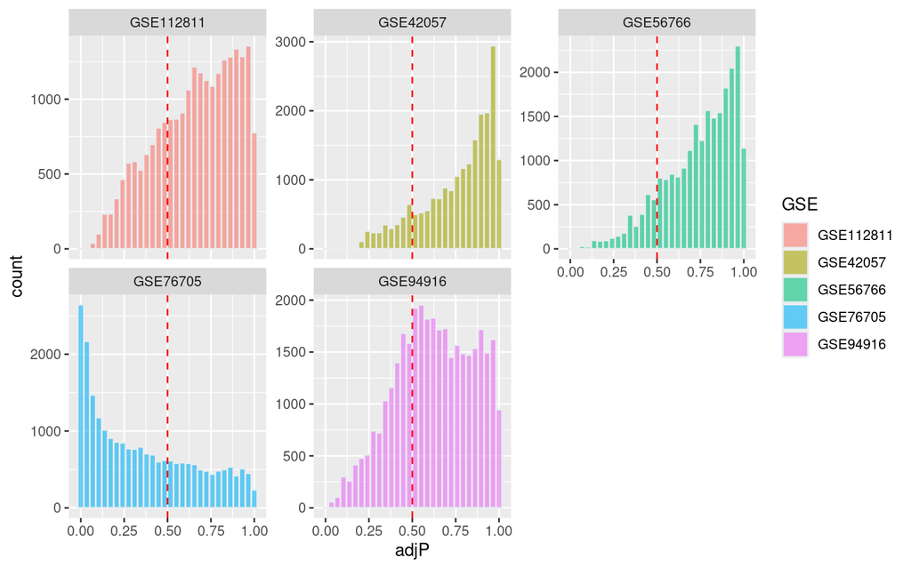

```r
#pdf("Pvalues.pdf",width = 8,height = 6)
adjp %>%
  group_by(GSE) %>%
  ggplot( aes(x=adjP, fill=GSE)) +
  geom_histogram( color="#e9ecef", alpha=0.6) + #position = 'identity'
  geom_vline(xintercept=0.5, linetype="dashed", color = "red") +
  facet_wrap(~GSE, scales = "free_y")
```

```r
#dev.off()

adj_pvalue <- 0.5
adjp <- filter(adjp,adjP < adj_pvalue)
unique(adjp$GSE)
```

```
## [1] "GSE112811" "GSE56766"  "GSE42057"  "GSE94916"  "GSE76705"
```

```r
adjp
```

```
## # A tibble: 38,558 x 3
##    GENE.SYMBOL GSE          adjP
##    <chr>       <chr>       <dbl>
##  1 PRELID1     GSE112811 0.00412
##  2 SGMS2       GSE112811 0.0692
##  3 PID1        GSE112811 0.0692
##  4 PRRC2C      GSE112811 0.0692
##  5 MGST1       GSE112811 0.0692
##  6 ACE         GSE112811 0.0692
##  7 SOGA1       GSE112811 0.0692
##  8 SLPI        GSE112811 0.0692
##  9 CD36        GSE112811 0.0692
## 10 ARMC2-AS1   GSE112811 0.0706
## # … with 38,548 more rows
```

```r
# log fold change
logFC <- full_tables %>%
  filter(GENE.SYMBOL != "NA") %>%
  gather("GSE"  ,"logFC",-GENE.SYMBOL) %>%
  filter(GSE %in% str_subset(colnames(full_tables),"logFC")) %>%
  mutate(GSE=gsub(".*_","",GSE))

logFC
```

```
## # A tibble: 205,465 x 3
##    GENE.SYMBOL GSE        logFC
##    <chr>       <chr>      <dbl>
##  1 PRELID1     GSE112811  0.246
##  2 SGMS2       GSE112811  0.856
##  3 PID1        GSE112811  0.727
##  4 PRRC2C      GSE112811 -0.198
##  5 MGST1       GSE112811  0.492
##  6 ACE         GSE112811 -0.547
##  7 SOGA1       GSE112811 -0.405
##  8 SLPI        GSE112811  1.32
##  9 CD36        GSE112811  0.995
## 10 ARMC2-AS1   GSE112811  0.257
## # … with 205,455 more rows
```

```r
# recovering logFC values from genes with p value less than 0.01

ap <- left_join(adjp,logFC,by = c("GENE.SYMBOL" = "GENE.SYMBOL", "GSE" = "GSE")) %>%
  select(-adjP) %>%
  spread(GSE,logFC) %>%
  replace(is.na(.), 0)

ap
```

```
## # A tibble: 23,824 x 6
##    GENE.SYMBOL GSE112811 GSE42057 GSE56766 GSE76705 GSE94916
##    <chr>           <dbl>    <dbl>    <dbl>    <dbl>    <dbl>
##  1 A1BG           0.140         0    0       0.0434    0
##  2 A1CF          -0.0810        0    0       0.0520    0
##  3 A2M           -0.236         0    0      -0.127     0.346
##  4 A2M-AS1        0             0   -0.322  -0.292     0.428
##  5 A2ML1          0             0    0       0.0451    0
##  6 A2MP1          0             0    0      -0.228     0
##  7 AA06           0             0    0       0.0421    0
##  8 AACS           0             0    0       0        -0.830
##  9 AADAC          0             0    0       0        -0.672
## 10 AADACL2        0             0    0       0        -0.954
## # … with 23,814 more rows
```

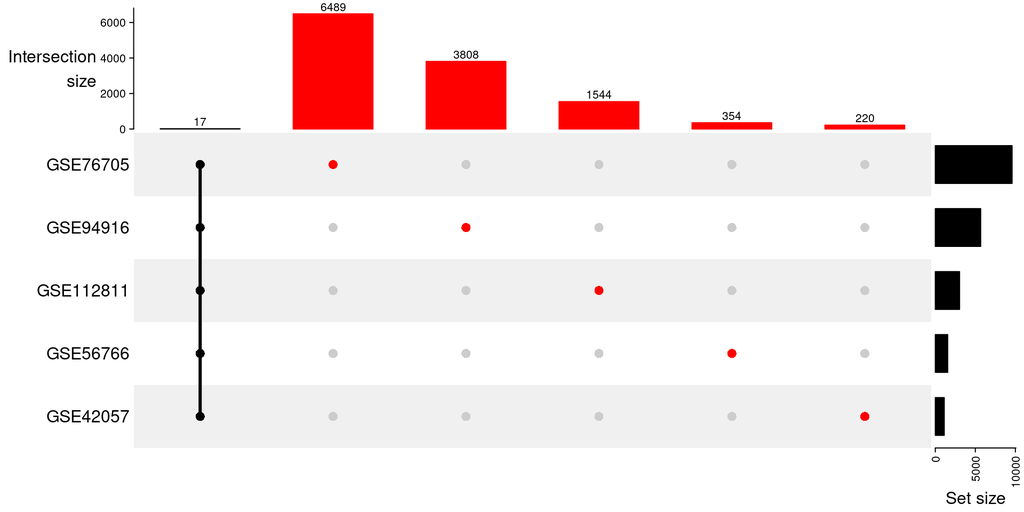

```r
# selecting up regulated genes
up <- ap %>%
  mutate_at(vars(-GENE.SYMBOL),list(~if_else( .>0, 1, 0)))

down <- ap %>%
  mutate_at(vars(-GENE.SYMBOL),list(~if_else( .<0, 1, 0)))

### UP
m <- make_comb_mat(up,mode = "distinct")
m <- m[comb_degree(m) >= 5 | comb_degree(m) == 1]

#pdf("upsetUP.pdf",width = 14,height = 6)
ht <- draw(UpSet(m,
      pt_size = unit(3, "mm"),
      lwd = 3,
      comb_col = c("red", "grey","grey","grey", "black","blue")[comb_degree(m)])
      #order.by = "freq"
    )

od = column_order(ht)
cs = comb_size(m)
decorate_annotation("Intersection\nsize", {
    grid.text(cs[od], x = seq_along(cs), y = unit(cs[od], "native") + unit(2, "pt"),
        default.units = "native", just = "bottom", gp = gpar(fontsize = 8))
})
```

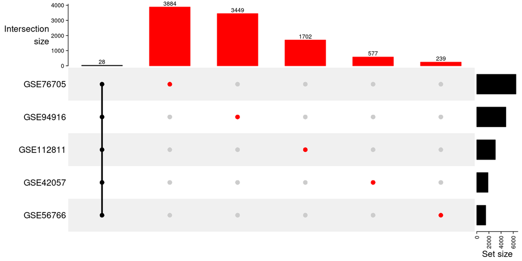

```r
#dev.off()


### DOWN
m <- make_comb_mat(down,mode = "distinct")
m <- m[comb_degree(m) >= 5 | comb_degree(m) == 1]

#pdf("upsetDOWN.pdf",width = 14,height = 6)
ht <- draw(UpSet(m,
      pt_size = unit(3, "mm"),
      lwd = 3,
      comb_col = c("red", "grey","grey","grey", "black","blue")[comb_degree(m)])
      #order.by = "freq"
    )
#dev.off()

od = column_order(ht)
cs = comb_size(m)
decorate_annotation("Intersection\nsize", {
    grid.text(cs[od], x = seq_along(cs), y = unit(cs[od], "native") + unit(2, "pt"),
        default.units = "native", just = "bottom", gp = gpar(fontsize = 8))
})
```

## Meta-analysis

We first calculate the Standar error using confidence intervals

```r
CI.R <- str_subset(colnames(full_tables),"CI.R")
CI.L <- str_subset(colnames(full_tables),"CI.L")

for(i in 1:length(CI.R)) {
  full_tables[str_c("SE_",gsub(".*_","",CI.R))] <- (full_tables[,CI.R]-full_tables[,CI.L]) /(2*1.96)
}
```

Meta-analysis for a single gene

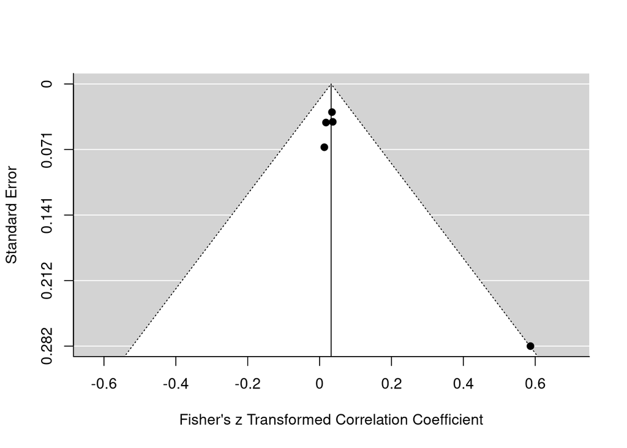

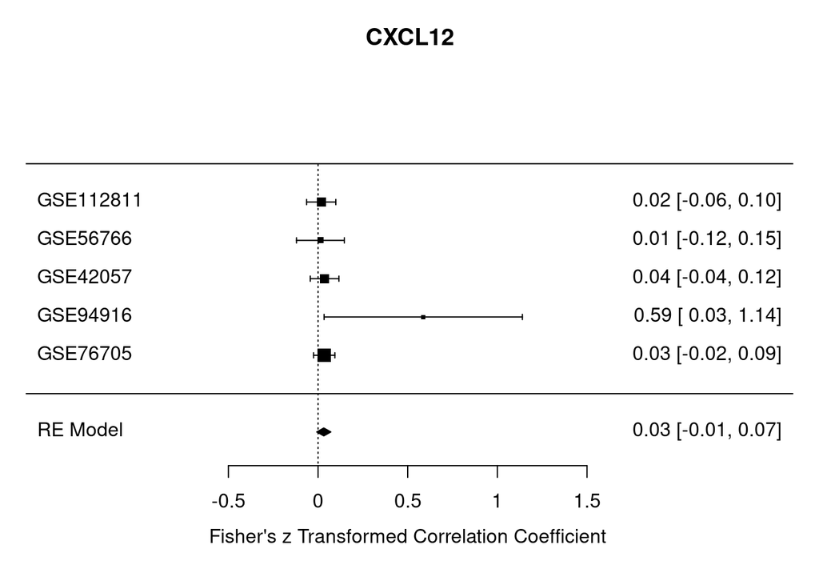

```r
FC <- str_subset(colnames(full_tables),"logFC")
SE <- str_subset(colnames(full_tables),"SE_")
GSE <- gsub(".*_","",FC)

gs <- "CXCL12"

## Funtion to perform a meta-analysis per gene
meta.plot <- function(gs){
gene <-  full_tables[full_tables$GENE.SYMBOL == gs,]
#gene <-  na.omit(full_tables[full_tables$GENE.SYMBOL == gs,])
gene <- gene[!is.na(gene$GENE.SYMBOL),]

dat <- data.frame(
  yi = as.numeric(gene[,FC]),
  sei = as.numeric(gene[,SE]),
  n1i = as.numeric(gse_table$CONTROL),
  n2i = as.numeric(gse_table$COPD)
)



dat <- escalc(measure="ZCOR", yi=yi,sei=sei,n1i=n1i,n2i=n2i, data = dat)

# meta analysis in the simplest way
res <- metafor::rma(yi, sei=sei,n1i=n1i,n2i=n2i, data=dat)
funnel(res)
forest(res,slab = GSE, main=unique(gene$GENE.SYMBOL))
}

meta.plot(gs)
```

Meta-analysis for all genes. We are saving the results in a new dataframe.

```r
#gs <- unique(na.omit(full_tables)$GENE.SYMBOL)
gs <- full_tables$GENE.SYMBOL


meta <- data.frame(genes = 0,
                   QEp=0,
                   estimate=0,
                   pval=0,
                   se=0,
                   H2=0,
                   tau2=0,
                   I2=0,
                   num_exp=0)

gm <- full_tables$GENE.SYMBOL
full_tables[full_tables == 0] <- NA

length(gm)
```

```
## [1] 41093
```

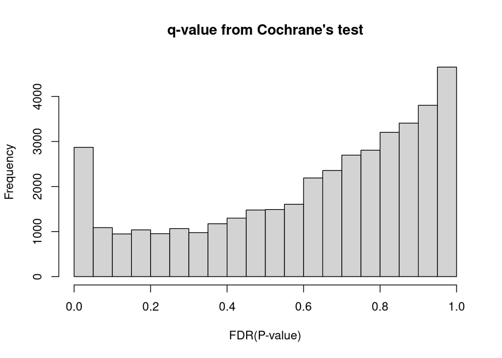

```r
for (i in gm) {
  gene <- full_tables[which(full_tables$GENE.SYMBOL == i),]
  yi <- as.numeric(gene[,FC])
  sei <- as.numeric(gene[,SE])
  num_exp <- sum(!is.na(yi))
  # meta analysis with random models "REML"
  res <- suppressWarnings(metafor::rma(yi, sei=sei,control=list(stepadj=.5,maxiter=1000)))
  num_exp <- sum(!is.na(yi))
  meta <- rbind(meta,c(i,res$QEp,res$beta,res$pval,res$se,res$H2,res$tau2,res$I2,num_exp))
}



meta <- meta[-1,]
meta$QEp <- as.numeric(meta$QEp)
meta$pval <- as.numeric(meta$pval)

# FDR correction
meta$qval <- p.adjust(meta$pval,method="fdr")


write.csv(meta, OUTPUT(c(TODAY,"_Step6_meta-analysis.csv")))
meta <- read.csv(OUTPUT(c(TODAY,"_Step6_meta-analysis.csv")))

hist(meta$qval, main="q-value from Cochrane's test", xlab="FDR(P-value)")
```

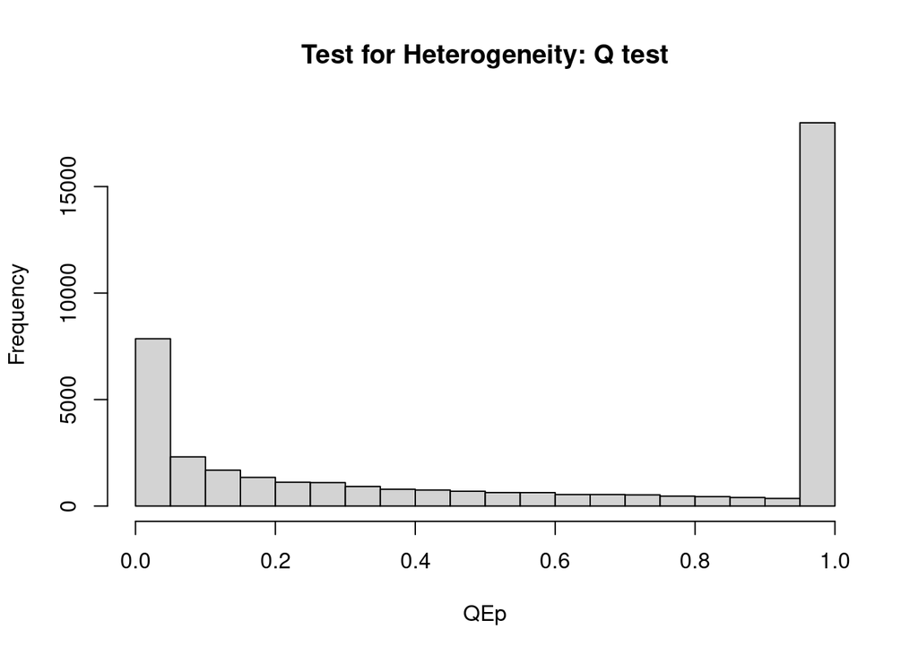

```r
hist(meta$QEp, main="Test for Heterogeneity: Q test", xlab="QEp")
```

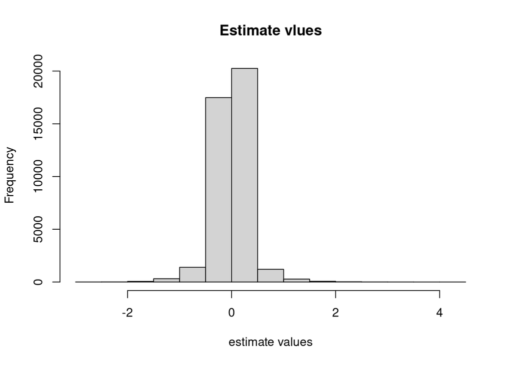

```r
hist(meta$estimate, main = "Estimate vlues", xlab = "estimate values")
```

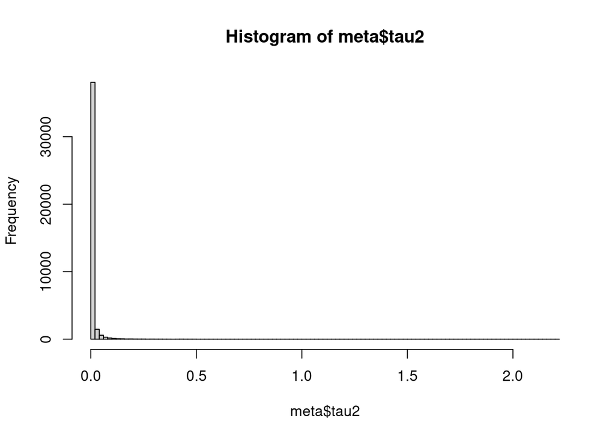

```r
hist(meta$tau2,100)
```

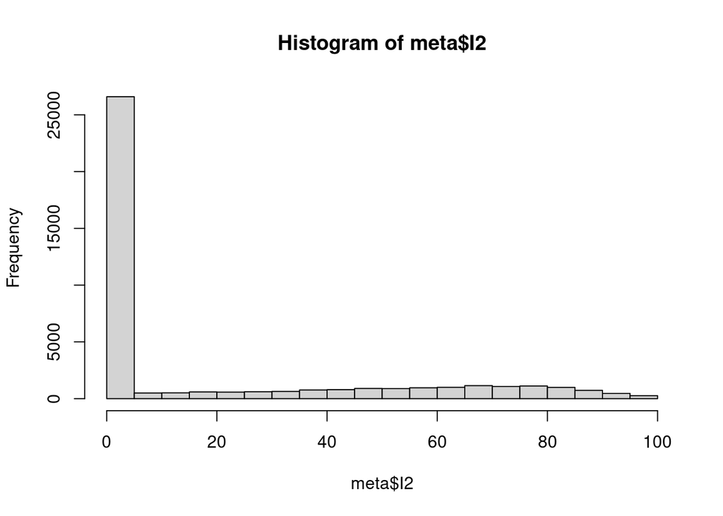

```r
hist(meta$I2)
```

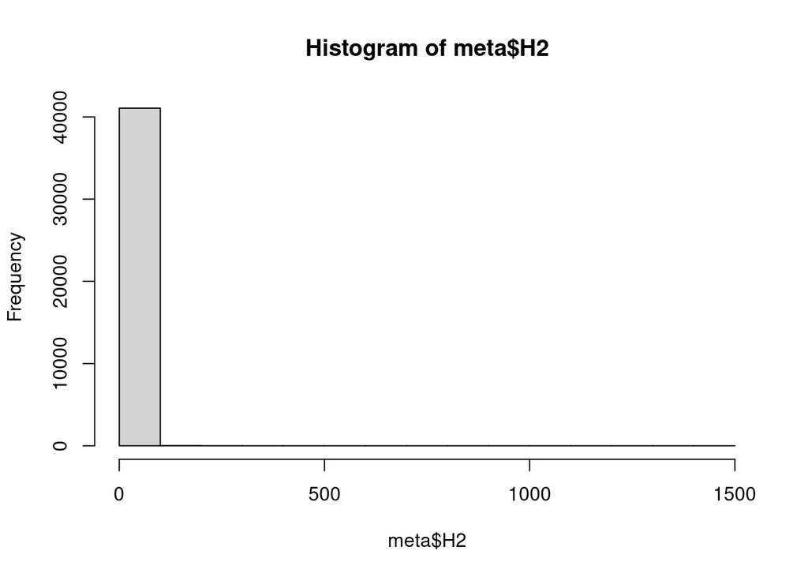

```r
hist(meta$H2)
```

```r
qval_cutoff <- 0.01
genesqval <- meta[meta$qval <= qval_cutoff,]
#genesqval <- genesqval[genesqval$QEp < 0.2,]
genesqval <-  genesqval[order(genesqval$qval),]

#genesqval <- genesqval[genesqval$num_exp > 2, ]
#genesqval <- genesqval[abs(genesqval$estimate) > .3, ]

kable(genesqval, caption = "Meta-analysis")
```

Meta-analysis

|  | X | genes | QEp | estimate | pval | se | H2 | tau2 | I2 | num_exp | qval |
| --- | --- | --- | --- | --- | --- | --- | --- | --- | --- | --- | --- |
| 797 | 798 | CCR6 | 0.0197271 | -0.3699712 | 0.0000000 | 0.0484865 | 1.000036 | 0.0000006 | 0.0036124 | 5 | 0.0000000 |
| 9364 | 9365 | NMT2 | 0.1223421 | -0.2894123 | 0.0000000 | 0.0379957 | 1.000226 | 0.0000024 | 0.0225994 | 5 | 0.0000000 |
| 5617 | 5618 | LBH | 0.6720839 | -0.2055330 | 0.0000000 | 0.0279634 | 1.000019 | 0.0000001 | 0.0019076 | 5 | 0.0000000 |
| 3633 | 3634 | ATF7IP2 | 0.2727558 | -0.2552807 | 0.0000000 | 0.0354702 | 1.000381 | 0.0000030 | 0.0380526 | 5 | 0.0000000 |
| 187 | 188 | SERPINB1 | 0.4872346 | 0.1865383 | 0.0000000 | 0.0262768 | 1.000000 | 0.0000000 | 0.0000000 | 5 | 0.0000000 |
| 2609 | 2610 | SLC8A1 | 0.7068829 | 0.3459507 | 0.0000000 | 0.0487508 | 1.000000 | 0.0000000 | 0.0000000 | 5 | 0.0000000 |
| 59 | 60 | IL13RA1 | 0.0780262 | 0.2393883 | 0.0000000 | 0.0340179 | 1.000032 | 0.0000002 | 0.0032107 | 5 | 0.0000000 |
| 2025 | 2026 | ST6GAL1 | 0.6173957 | -0.1873269 | 0.0000000 | 0.0269352 | 1.001746 | 0.0000081 | 0.1742764 | 5 | 0.0000000 |
| 886 | 887 | ENTPD1 | 0.4432279 | 0.2566593 | 0.0000000 | 0.0374762 | 1.000800 | 0.0000076 | 0.0799384 | 5 | 0.0000000 |
| 4309 | 4310 | FOXO1 | 0.7478784 | -0.2095981 | 0.0000000 | 0.0305529 | 1.000127 | 0.0000007 | 0.0126739 | 5 | 0.0000000 |
| 352 | 353 | BCL7A | 0.0041393 | -0.2783480 | 0.0000000 | 0.0409390 | 1.000000 | 0.0000000 | 0.0000000 | 5 | 0.0000000 |
| 4174 | 4175 | ANKH | 0.4579093 | -0.1947863 | 0.0000000 | 0.0286552 | 1.000440 | 0.0000022 | 0.0439845 | 5 | 0.0000000 |
| 358 | 359 | PPM1K | 0.1708673 | -0.2049602 | 0.0000000 | 0.0303139 | 1.000052 | 0.0000003 | 0.0051689 | 5 | 0.0000000 |
| 39229 | 39230 | LOC388210 /// LOC400499 | 1.0000000 | 0.4958157 | 0.0000000 | 0.0735764 | 1.000000 | 0.0000000 | 0.0000000 | 1 | 0.0000000 |
| 90 | 91 | SYNRG | 0.3948291 | -0.1514761 | 0.0000000 | 0.0225874 | 1.000194 | 0.0000006 | 0.0193798 | 5 | 0.0000001 |
| 1361 | 1362 | CD63 | 0.6175184 | 0.1101497 | 0.0000000 | 0.0164335 | 1.000254 | 0.0000005 | 0.0254114 | 5 | 0.0000001 |
| 147 | 148 | IRAK3 | 0.1301604 | 0.3280906 | 0.0000000 | 0.0490899 | 1.000348 | 0.0000055 | 0.0347863 | 5 | 0.0000001 |
| 2708 | 2709 | PATZ1 | 0.1505908 | -0.1371304 | 0.0000000 | 0.0205092 | 1.001376 | 0.0000036 | 0.1374384 | 5 | 0.0000001 |
| 784 | 785 | SORT1 | 0.0549199 | 0.2136757 | 0.0000000 | 0.0320735 | 1.000039 | 0.0000003 | 0.0038785 | 5 | 0.0000001 |
| 1154 | 1155 | DUSP3 | 0.5696118 | 0.1877872 | 0.0000000 | 0.0281970 | 1.000000 | 0.0000000 | 0.0000000 | 5 | 0.0000001 |
| 47 | 48 | ATP8B2 | 0.4864084 | -0.2003173 | 0.0000000 | 0.0301137 | 1.000534 | 0.0000030 | 0.0534115 | 5 | 0.0000001 |
| 11391 | 11392 | PRRG4 | 0.9064875 | 0.3443983 | 0.0000000 | 0.0521069 | 1.000000 | 0.0000000 | 0.0000000 | 5 | 0.0000001 |
| 501 | 502 | SMARCD3 | 0.3024613 | 0.2305666 | 0.0000000 | 0.0350070 | 1.000271 | 0.0000019 | 0.0270721 | 5 | 0.0000001 |
| 2343 | 2344 | LY9 | 0.7964893 | -0.2211357 | 0.0000000 | 0.0335853 | 1.000000 | 0.0000000 | 0.0000000 | 5 | 0.0000001 |
| 4698 | 4699 | REPS2 | 0.7294486 | 0.2762937 | 0.0000000 | 0.0421605 | 1.000468 | 0.0000054 | 0.0467859 | 5 | 0.0000001 |
| 2502 | 2503 | NOL9 | 0.8606082 | -0.1376115 | 0.0000000 | 0.0210555 | 1.000000 | 0.0000000 | 0.0000000 | 5 | 0.0000001 |
| 16693 | 16694 | TRAF5 | 0.6323919 | -0.2428761 | 0.0000000 | 0.0371833 | 1.000000 | 0.0000000 | 0.0000000 | 5 | 0.0000001 |
| 1317 | 1318 | IKZF1 | 0.2783406 | -0.1302290 | 0.0000000 | 0.0200616 | 1.000000 | 0.0000000 | 0.0000000 | 5 | 0.0000001 |
| 7630 | 7631 | ETS1 | 0.1211708 | -0.1775962 | 0.0000000 | 0.0274656 | 1.000231 | 0.0000011 | 0.0231337 | 5 | 0.0000001 |
| 1044 | 1045 | RIT1 | 0.2611506 | 0.2054069 | 0.0000000 | 0.0320244 | 1.000354 | 0.0000023 | 0.0353945 | 5 | 0.0000002 |

[output cut: 1475 more lines]

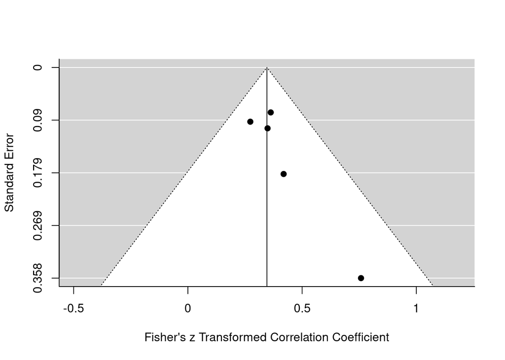

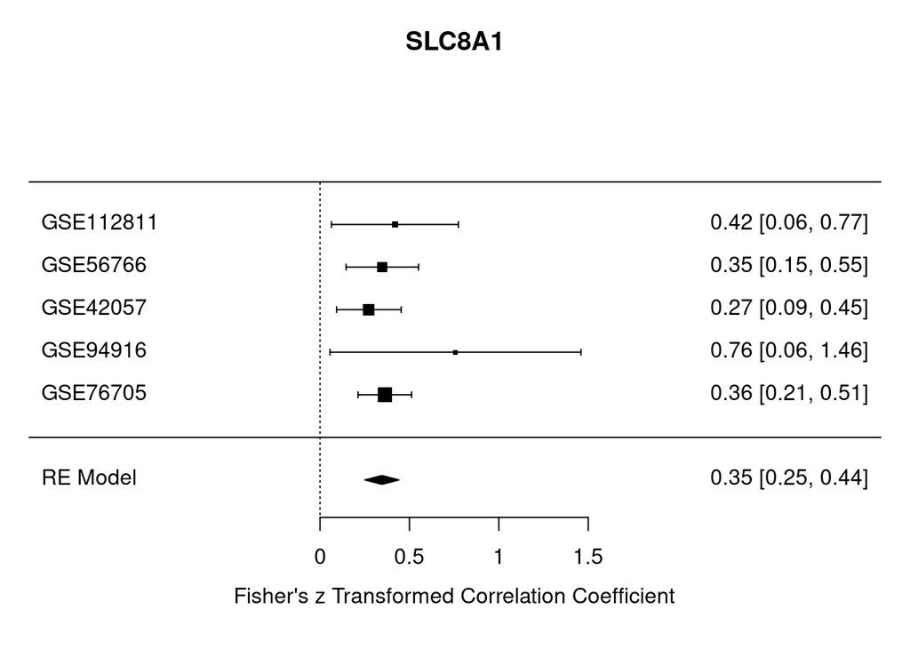

```r
up <- "SLC8A1"
down <- "MS4A1"
ace2 <- "AFF3"

meta.plot(up)
```

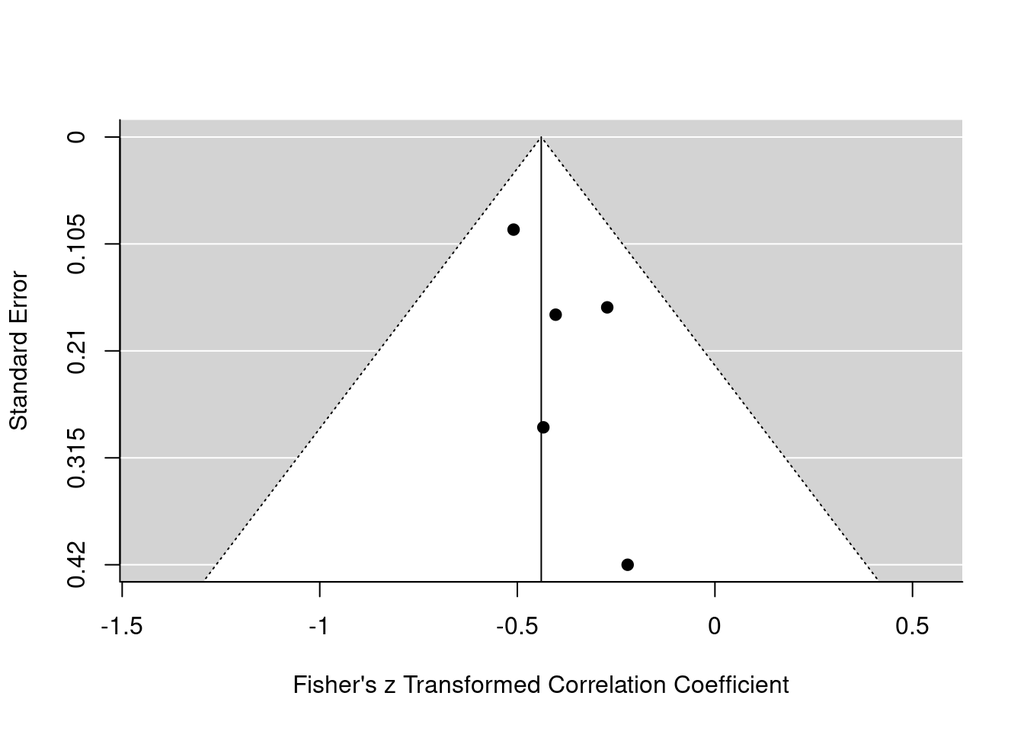

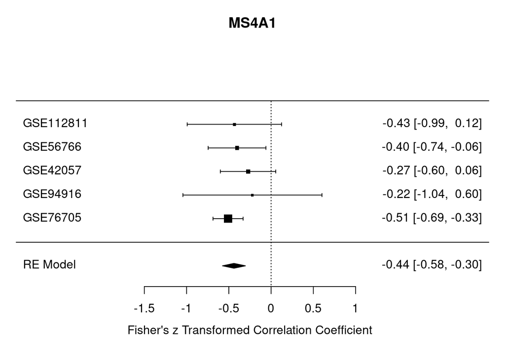

```r
meta.plot(down)
```

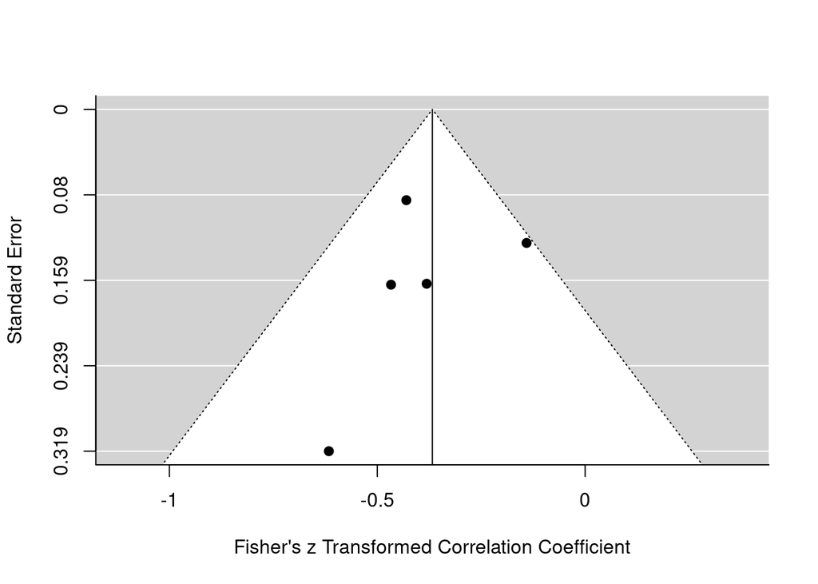

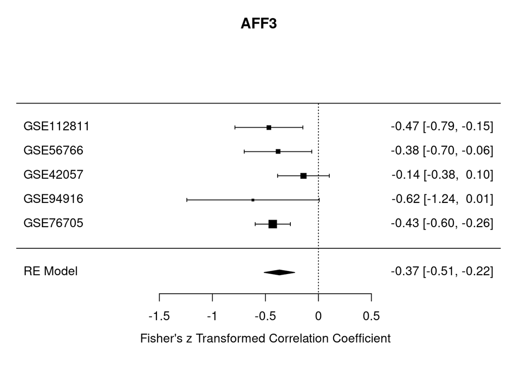

```r
meta.plot(ace2)
```

```r
topgenes <- full_tables[full_tables$GENE.SYMBOL %in% genesqval$genes,c("GENE.SYMBOL",FC)]
topgenes <- column_to_rownames(topgenes,"GENE.SYMBOL")

topgenes <- scale(topgenes)

# keeping genes with less than 2 NAs
topgenes <- topgenes[which(rowSums(is.na(topgenes)) <= 2),]
#topgenes <- na.omit(topgenes)

#ordering rows
#topgenes <- topgenes[order(rowMeans(topgenes),decreasing = T),]

#"BrBG"
color <- rev(colorRampPalette(brewer.pal(n = 11, name = "RdBu"))(15))
breaks <- c(seq(min(topgenes,na.rm = T),-0.1,length.out = 7),0,seq(0.1,max(topgenes,na.rm = T),length.out = 7))
```

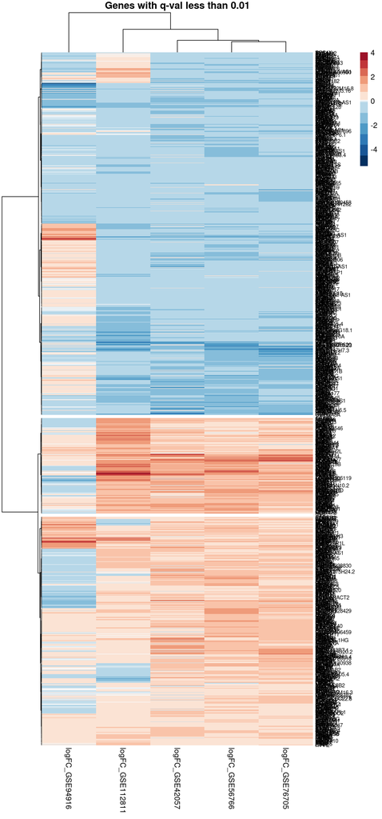

```r
pheatmap(topgenes,
         main = str_c("Genes with q-val less than ",qval_cutoff),
         color = color,
         breaks = breaks,
         fontsize_row = 7,
         fontsize_col = 10,
         cluster_rows = T,
         clustering_distance_rows = "euclidean",
         clustering_method = "ward.D",
         cluster_cols = T,
         cutree_rows = 3,
         show_colnames = T,
         border_color = NA)
```

### TFs

We also checked for expression in TFs

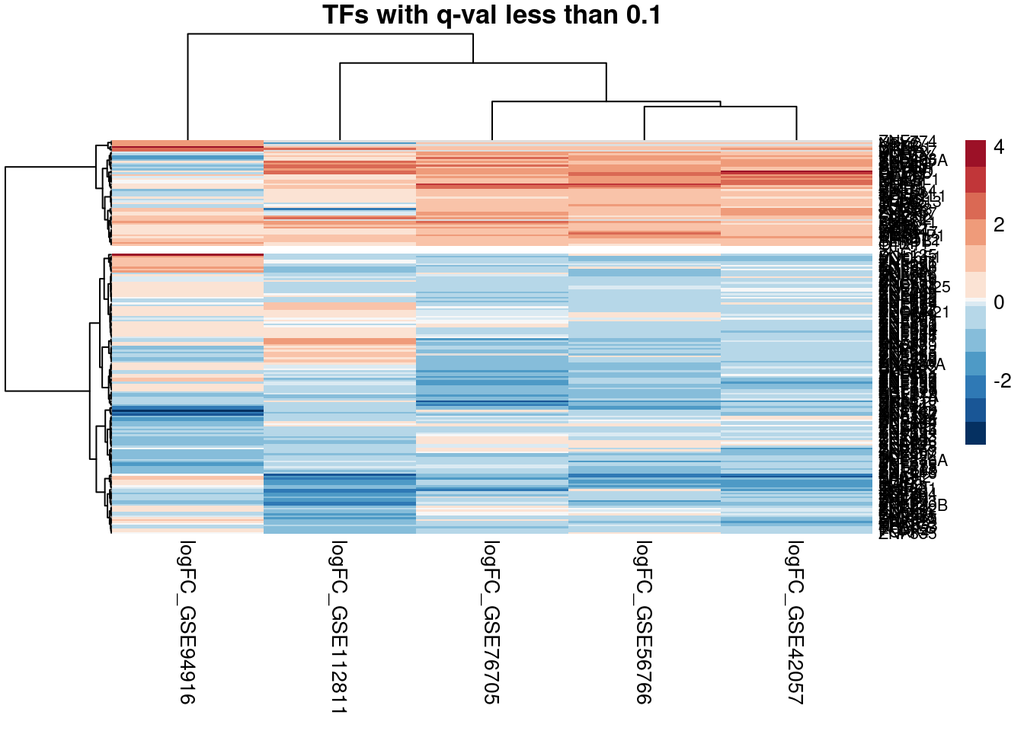

```r
tfs <- read.csv(here::here("Tissue/data/hs_hgnc_curated_tfs.txt"),col.names = "TF")

qval_cutoff <- 0.1
genesqval <- meta[meta$qval <= qval_cutoff,]
write.csv(genesqval[which(genesqval$genes %in% tfs$TF),], OUTPUT(c(TODAY,"_Step6_TF-",qval_cutoff,"-meta-analysis.csv")))
tf_copd <- genesqval$genes[which(genesqval$genes %in% tfs$TF)]

topgenes <- full_tables[full_tables$GENE.SYMBOL %in% tf_copd,c("GENE.SYMBOL",FC)]
topgenes <- column_to_rownames(topgenes,"GENE.SYMBOL")
topgenes <- scale(topgenes)
#topgenes <- na.omit(topgenes)


color <- rev(colorRampPalette(brewer.pal(n = 11, name = "RdBu"))(15))
breaks <- c(seq(min(topgenes,na.rm = T),-0.1,length.out = 7),0,seq(0.1,max(topgenes,na.rm = T),length.out = 7))

pheatmap(topgenes,
         main = str_c("TFs with q-val less than ",qval_cutoff),
         color = color,
         breaks = breaks,
         fontsize_row = 8,
         fontsize_col = 10,
         cluster_rows = T,
         clustering_distance_rows = "euclidean",
         clustering_method = "ward.D",
         cluster_cols = T,
         cutree_rows = 2,
         show_colnames = T,
         border_color = NA)
```

## Output

This script produces the following data, and can be found in /home/ana/DataDNA/R-projects/Meta-analysis_COPD

**Plots:** Upset plots, forest plot, heatmap, etc.  
**Table:** Results from the meta-analysis /home/ana/DataDNA/R-projects/Meta-analysis_COPD/Blood/output_data/Blood_2020-11-30_Step6_meta-analysis.csv